# Reproducible Research: Peer Assessment 1

- load all the libraries

```r
is.installed <- function(mypkg) is.element(mypkg, installed.packages()[,1])
if (is.installed('dplyr') == 'FALSE') {install.packages("dplyr")} else{library(dplyr)}
if (is.installed('ggthemes') == 'FALSE') {install.packages("ggthemes")} else{library(ggthemes)}
```

```r
if (is.installed('scales') == 'FALSE') {install.packages("scales")} else{library(scales)}
if (is.installed('RColorBrewer') == 'FALSE') {install.packages("RColorBrewer")} else{library(RColorBrewer)}
if (is.installed('lubridate') == 'FALSE') {install.packages("lubridate")} else{library(lubridate)}
if (is.installed('ggplot2') == 'FALSE') {install.packages("ggplot2")} else{library(ggplot2)}
if (is.installed('plyr') == 'FALSE') {install.packages("plyr")} else{library(plyr)}
if (is.installed('knitr') == 'FALSE') {install.packages("knitr")} else{library(knitr)}
if (is.installed('lattice') == 'FALSE') {install.packages("lattice")} else{library(lattice)}
if (is.installed('RCurl') == 'FALSE') {install.packages("RCurl")} else{library(RCurl)}
```

- Load the data (i.e. read.csv())
- Process/transform the data (if necessary) into a format suitable for your analysis
- Set working directory

```r
curdir <-getwd()
file.url<-'http://d396qusza40orc.cloudfront.net/repdata%2Fdata%2Factivity.zip'
download.file(file.url,destfile=paste(curdir,'/repdata%2Fdata%2Factivity.zip',sep=""))
unzip(paste(curdir,'/repdata%2Fdata%2Factivity.zip',sep=""),exdir=paste(curdir,sep=""),overwrite=TRUE)
```

- Read the CSV

```r
data <- read.csv(paste(curdir,'/activity.csv',sep=""))
```

- Ignore missing value

```r
dataClean <- subset(data, is.na(data$steps) == F)
totalPerDay <- ddply(dataClean, .(date), summarise, steps=sum(steps))
```

## What is mean total number of steps taken per day?

- If you do not understand the difference between a histogram and a barplot, research the difference between them. Make a histogram of the total number of steps taken each day
- Plot / Make a histogram of the total number of steps taken each day

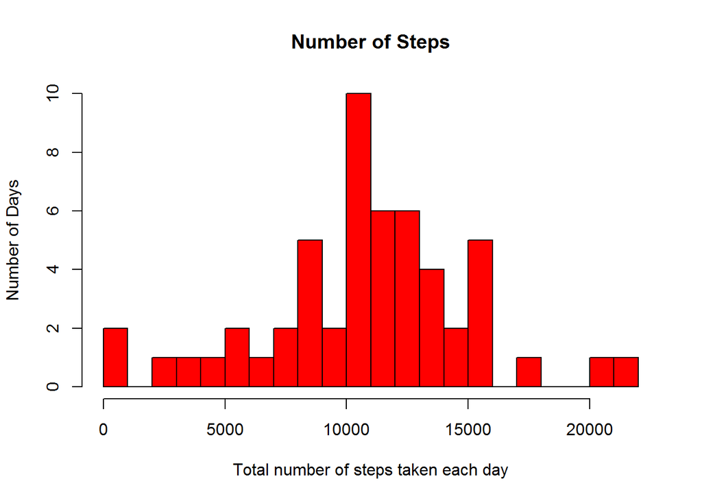

```r
hist(totalPerDay$steps , breaks = 20, main="Number of Steps",
     xlab="Total number of steps taken each day", ylab = "Number of Days",col="red")
```

- Calculate and report the mean and median of the total number of steps taken per day
- Mean

```r
mean(totalPerDay$steps)
```

```
## [1] 10766.19
```

- Median

```r
median(totalPerDay$steps)
```

```
## [1] 10765
```

## What is the average daily activity pattern?

- Make a time series plot (i.e. type = “l”) of the 5-minute interval (x-axis) and the average number of steps taken, averaged across all days (y-axis)
- Which 5-minute interval, on average across all the days in the dataset, contains the maximum number of steps?

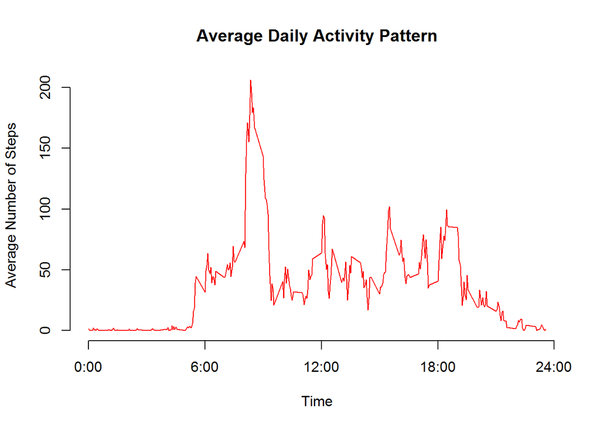

```r
averagePerInterval <- ddply(dataClean, .(interval), summarise, steps=mean(steps))
plot(averagePerInterval$interval, averagePerInterval$steps,axes = F, type="l", col="red", xlab="Time", ylab="Average Number of Steps",
     main="Average Daily Activity Pattern")
axis(1,at=c(0,600,1200,1800,2400), label = c("0:00","6:00","12:00","18:00","24:00"))
axis(2)
```

```r
maxSteps <- averagePerInterval[which.max(averagePerInterval$steps),] # 8.35 + 5-minute  = (8.35-8.40)
```

## Imputing missing values

- Calculate and report the total number of missing values in the dataset (i.e. the total number of rows with NAs)

```r
missingvalCount <- sum(is.na(data$steps))  # 2304
```

- Devise a strategy for filling in all of the missing values in the dataset. The strategy does not need to be sophisticated. For example, you could use the mean/median for that day, or the mean for that 5-minute interval, etc.
- Fill NA with the average value for each 5 minutes interval
- Create a new dataset that is equal to the original dataset but with the missing data filled in.

```r
missingValFillin  <- data
for (i in 1:nrow(missingValFillin )){
    if (is.na(missingValFillin $steps[i])){
        missingValFillin $steps[i] <- averagePerInterval$steps[which(missingValFillin $interval[i] == averagePerInterval$interval)]}
}

missingValFillin <- arrange(missingValFillin, interval) # sorting the data by interval
missingvalCount <- sum(is.na(missingValFillin$steps)) # 0 ; test count the missing value
```

- Make a histogram of the total number of steps taken each day and Calculate and report the mean and median total number of steps taken per day.
- Do these values differ from the estimates from the first part of the assignment?
- What is the impact of imputing missing data on the estimates of the total daily number of steps?
- TotalStepsMissingValueFillin

```r
totalPerDayStepsMissingvalueFillin <- ddply(missingValFillin, .(date), summarise, steps=sum(steps))
```

- Trying plot the data to investigate

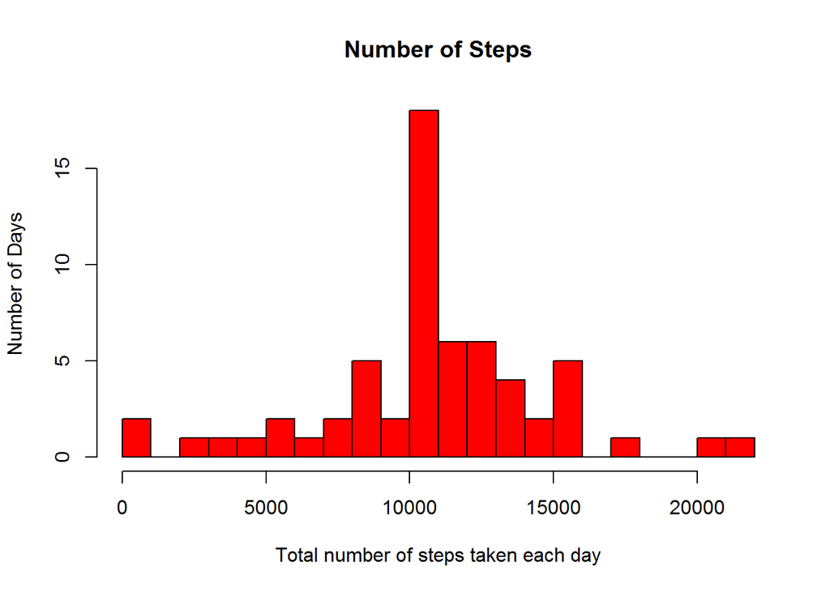

```r
hist(totalPerDayStepsMissingvalueFillin$steps, breaks = 20, main="Number of Steps", xlab="Total number of steps taken each day", ylab = "Number of Days",col="red")
```

```r
mean(totalPerDayStepsMissingvalueFillin$steps) # 10766.19
```

```
## [1] 10766.19
```

```r
median(totalPerDayStepsMissingvalueFillin$steps) # 10766.19
```

```
## [1] 10766.19
```

```r
abs(mean(totalPerDay$steps)-mean(totalPerDayStepsMissingvalueFillin$steps)) # 0
```

```
## [1] 0
```

```r
abs(median(totalPerDay$steps)- median(totalPerDayStepsMissingvalueFillin$steps))/median(totalPerDay$steps) #0.0001104207
```

```
## [1] 0.0001104207
```

```r
totalDifference <- sum(totalPerDayStepsMissingvalueFillin$steps) - sum(dataClean$steps)  # 86129.51
totalDifference
```

```
## [1] 86129.51
```

## Are there differences in activity patterns between weekdays and weekends?

- Create a new factor variable in the dataset with two levels - “weekday” and “weekend” indicating whether a given date is a weekday or weekend day.

```r
Sys.setlocale("LC_TIME", "English")
```

```
## [1] "English_United States.1252"
```

```r
missingValFillin$weekdays <- weekdays(as.Date(missingValFillin$date))
missingValFillin$weekdays <- ifelse(missingValFillin$weekdays %in% c("Saturday", "Sunday"),"weekend", "weekday")
average <- ddply(missingValFillin, .(interval, weekdays), summarise, steps=mean(steps))
```

- Make a panel plot containing a time series plot (i.e. type = “l”) of the 5-minute interval (x-axis) and the average number of steps taken, averaged across all weekday days or weekend days (y-axis).
- See the README file in the GitHub repository to see an example of what this plot should look like using simulated data.

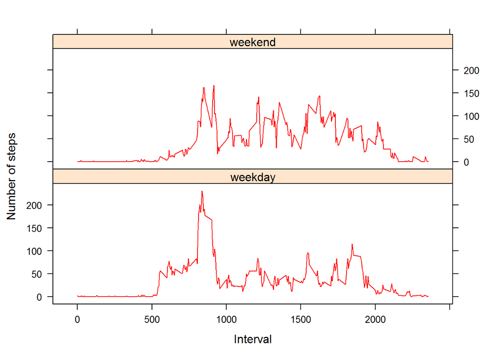

```r
xyplot(steps ~ interval | weekdays, data = average, layout = c(1, 2), type="l", xlab = "Interval", ylab = "Number of steps" , col="red")
```